# babies4801

2023-12-07

Monoligual and Bilingual Gaze Following

Statistical Approach

Using data from the “MB1G The Development of Gaze Following in Monolingual and Bilingual Infants”, we conducted three statistical tests, a repeated measures ANOVA, Tukey HSD, and an ANOVA with a predictor. For our first statistical test we compared how monolingual and bilingual infants compare in the length of gaze following. Our second analysis consisted of a follow up Tukey HSD test comparing the same sample group. Our final statistical analysis we tested age and the length of gaze following using an ANOVA with a predictor, monolingual or bilingual.

Results

After running our first statistical test which is a repeated measures ANOVA test, we found that the difference in language, monolingual or bilingual, has no statistical significance (F = 0.871). We used a Tukey analysis test to follow up, and again, we found no statistical significance. On or final analysis, using an ANOVA test, analyzing age and gaze following (F = 1.013) with a predictor of language (F = 1.034), we also found to be not significant.

Analysis 1

Repeated measures ANOVA

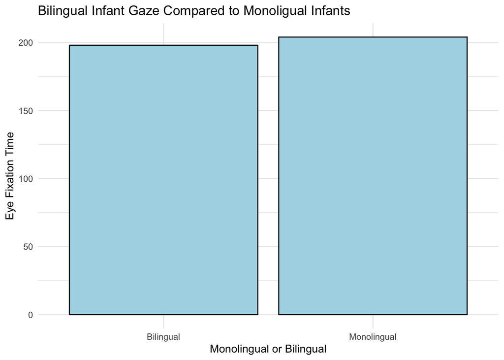

Analysis 2

ANOVA with predictor

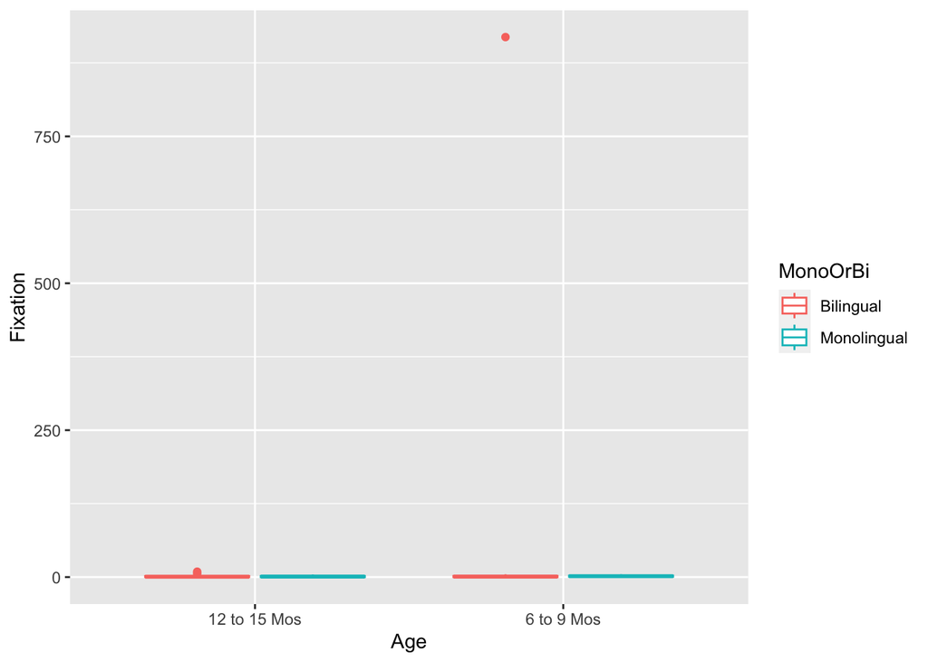